# TD3 Econometric

Cabal Paul-Louis

2022-11-01

TIME SERIES ANALYSIS - LAB SESSION 3 ESILV : Master 1 - 2022/2023 Dynamic model

# Part 1

## Exercice 2

Question 1 :

Simulate an ARMA(p,q) process. You are free to select numbers for p and q.

```r
Sarma22 = arima.sim(list(order=c(2,0,2), ma=c (1.1, -0.28), ar=c(0.6,-0.25)), n=1000 , n.start = NA)
```

Question 2 :

Verify your ARMA(p,q) process does not respect the required conditions to be stationary. Use all the tools you know to reply to this question.

```r
#arma22p = arima.sim(list(order=c(2,0,2), ma=c (-0.5, 0.5), ar=c(-0.5,0.5)), n=1000 , n.start = NA)
#arma22p
```

With a stationnary Arma we can figured it out by plotting the square value and verify that it’s in the unit circle

```r
#install.packages("tseries")
#install.packages("forecast")
```

```r
library(forecast)
library(tseries)
```

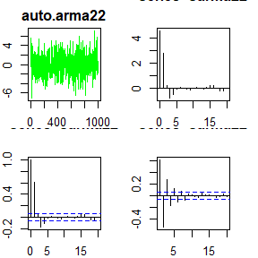

```r
Sarma22 = arima.sim(list(order=c(2,0,2), ma=c (1.1, -0.28), ar=c(0.6,-0.25)), n=1000 , n.start = NA)

par(mfrow=c(2,2))
par(mar = rep(2, 4))

plot(Sarma22, type="l", col="green", main="auto.arma22")
acf(Sarma22, lag = 20, type = "covariance")
acf(Sarma22, lag = 20, type = "correlation")
pacf(Sarma22, lag = 20)
```

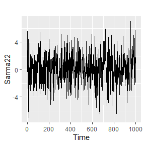

```r
autoplot(Sarma22)
```

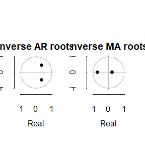

```r
fit = Arima(Sarma22, order=c(2,0,2))
plot(fit)
```

Question 3 :

```r
#Box.test(arma22p, lag = 12, type = "Ljung")

Box.test(Sarma22, lag = 12, type = "Ljung")
```

```
#>
#>  Box-Ljung test
#>
#> data:  Sarma22
#> X-squared = 420.95, df = 12, p-value < 2.2e-16
```

p_value near of 0, so the realizations aren’t independant (wich is normal)

# Part 2

We continue the study of ARMA models using the US Producer Price Index (excluding fresh food and energy). The data are available since 1974 until now. Can the ARMA framework help us to model the dynamics of this key variable and anticipate its behavior ?

Question 1 :

Load the PPI data from your workspace. Convert and plot the time series. Can the producer prices index be modeled without any transformation ? Explain.

```r
library('forecast')
library('tseries')

data1 = read.csv ("usppi.csv")
data1
```

```
#>              X usppi
#> 1    1/15/1974  47.5
#> 2    2/15/1974  48.1
#> 3    3/15/1974  49.5
#> 4    4/15/1974  50.9
#> 5    5/15/1974  52.5
#> 6    6/15/1974  53.7
#> 7    7/15/1974  55.2
#> 8    8/15/1974  57.0
#> 9    9/15/1974  57.6
#> 10  10/15/1974  58.2
#> 11  11/15/1974  58.8
#> 12  12/15/1974  59.1
#> 13   1/15/1975  59.6
#> 14   2/15/1975  59.8
```

[output cut: 572 more lines]

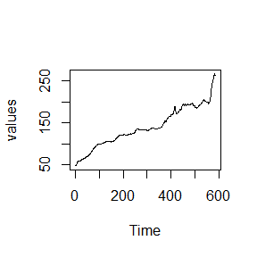

```r
attach(data1)

values = usppi
ts.plot (values)
```

The plotted time series seems to have a trend so not stationary, let’s verify it :

```r
#adf.test(usppi)
```

Error in adf.test(usppi) : NAs in x, so it’s not stationnary

Question 2 : Calculate the monthly growth rate of the PPI between January 1981 and December 2021. Can the PPI inflation be modeled now with an ARMA(p,q) ?

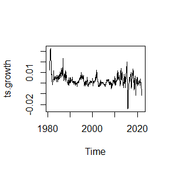

```r
growth = data1$usppi[2:nrow(data1)]/data1$usppi[1:(nrow(data1)-1)]-1
ts.growth = ts(growth, start = c(1981,1), end = c(2021, 12), frequency = 12)



plot(ts.growth, type='l')
```

It was trendy so we correct it but there is still seasonality

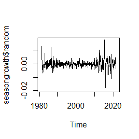

```r
seasongrowth  = decompose(ts.growth, type = "additive")
plot(seasongrowth$random)
```

Now we can modelize it with an ARMA(p,q) process !

Question 3 : Identification : Use the ACF and the PACF to identify the most appropriate lags to model this inflation rate.

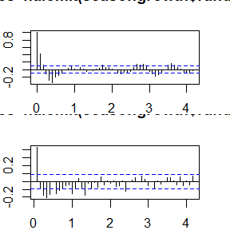

```r
par(mfrow=c(2,1))
par(mar = rep(2, 4))

acf(na.omit(seasongrowth$random),lag.max = 50, type = "correlation")
acf(na.omit(seasongrowth$random),lag.max = 50, type = "partial")
```

```r
# Il semblerait qu'un ARMA(4,4) soit une bon modèle car les ACF et PACF sont nuls
# à ces niveaux de lags
```

The ACF and PACF are near 0 with this lag level so an arma(4,4) could be a good model

Question 4/5 : Using the arima.sim function calculate the likelihood values for different combination p and q 1 . Calculate then the values of the Akaike and the Bayesian information criteria for all the couple p and q. Which combination of p and q is qualified according to the Akaike and the Bayesian criteria ?

```r
p = seq(0,5)
q = seq(0,5)
lik = matrix(0,nrow = max(p),ncol = max(q))
aic = matrix(0,nrow = max(p),ncol = max(q))
bic = matrix(0,nrow = max(p),ncol = max(q))


for (i in p) {
  for (j in q) {
    mdl = arima(na.omit(seasongrowth$random), order = c(i,0,j))
    lik[i,j] = mdl$loglik
    aic[i,j] = mdl$aic
    bic[i,j] = BIC(mdl)
  }
}


```

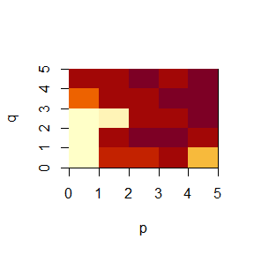

```r
image(p,q,lik) # Likelihood values
```

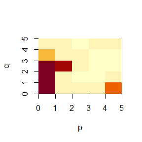

```r
image(p,q,aic) # Akaike information criterias
```

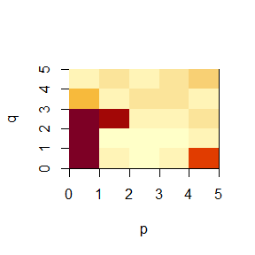

```r
image(p,q,bic) # Bayesian information criterias
```

Question 6/7 : . Estimation : Estimate the coefficients of the specification you selected in the previous question. To do so, use the package arima.sim. Calculate the yˆt and estimated residuals as well (ˆϵ).

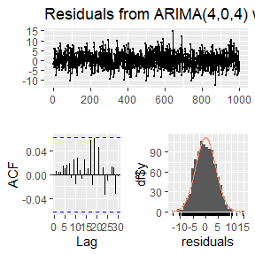

[output not shown]

```r
arma44 = arima.sim(list(order=c(4,0,4), ma=c (1.1, -0.28,2,4), ar=c(0.6,-0.25,0.25,-0.6)), n=1000 , n.start = NA)
#arma44



fit3 = arima(arma44,order = c(4,0,4) )
checkresiduals(fit3)
```

```r
Box.test(arma44, lag = 50, type = "Ljung")
```

```
#>
#>  Box-Ljung test
#>
#> data:  arma44
#> X-squared = 2452.8, df = 50, p-value < 2.2e-16
```

## Exercise 4 : The US stock market

```r
data2 = read.csv ("us_stock_data.csv")
data2
```

```
#>             X usindex
#> 1    1/1/1990  353.40
#> 2    2/1/1990  328.79
#> 3    3/1/1990  332.74
#> 4    4/1/1990  338.70
#> 5    5/1/1990  332.25
#> 6    6/1/1990  363.16
#> 7    7/1/1990  359.54
#> 8    8/1/1990  355.52
#> 9    9/1/1990  322.56
#> 10  10/1/1990  314.94
#> 11  11/1/1990  307.02
#> 12  12/1/1990  324.10
#> 13   1/1/1991  330.22
#> 14   2/1/1991  343.05
```

[output cut: 380 more lines]

```r
attach(data2)
```

```
#> L'objet suivant est masqué depuis data1:
#>
#>     X
```